# IST-718 Lab 3

# Fashion Mnist Image Prediction

#### ThulasiRam RuppaKrishnan IST 718 Professor: Jillian Lando

## Introduction

Image recognition refers to technologies that identify places, logos, people, objects, buildings, and several other variables in images. Users are sharing vast amounts of data through apps, social networks, and websites. Additionally, mobile phones equipped with cameras are leading to the creation of limitless digital images and videos. The large volume of digital data is being used by companies to deliver better and smarter services to the people accessing it. The image recognition market is estimated to grow from USD 15.95 Billion in 2016 to USD 38.92 Billion by 2021, at a CAGR of 19.5% between 2016 and 2021 (source https://www.transparencymarketresearch.com/image-recognition-market.html). Advancements in machine learning and use of high bandwidth data services is fueling the growth of this technology. Companies in different sectors such as e-commerce, automotive, healthcare, and gaming are rapidly adopting image recognition.

[figure not shown]

Image recognition is a part of computer vision and a process to identify and detect an object or attribute in a digital video or image. Computer vision is a broader term which includes methods of gathering, processing and analyzing data from the real world. The data is high-dimensional and produces numerical or symbolic information in the form of decisions. Apart from image recognition, computer vision also includes event detection, object recognition, learning, image reconstruction and video tracking. The major steps in image recognition process are gather and organize data, build a predictive model and use it to recognize images.

Practical applications for image recognition are very broad in nature and has numerous benefits for the human life conditions. Here are the few examples that has positive impacts on human beings and for their advancement as technological species in the known universe.

**Use Case #1: Bladder Cancer Identification Using Medical Image Recognition**

Image recognition of the human body is expected to improve drastically to help doctors with better and more accurate medical diagnostics. ML applied to image recognition of organs, even in the presence of disease, can minimize the possibility of medical errors and speed up disease diagnosis.

**Use Case #2: Crop Disease Identification**

One potential application is the development of mobile disease diagnostics through Image recognition, Deep Learning and crowdsourcing. The results of the engagement were very impressive in scoring different types of crops and their risk to unhealthy situations

## Analysis and Models

### About the data

Fashion-MNIST is a dataset of Zalando's article images—consisting of a training set of 60,000 examples and a test set of 10,000 examples. Each example is a 28x28 grayscale image, associated with a label from 10 classes. Zalando intends Fashion-MNIST to serve as a direct drop-in replacement for the original MNIST dataset for benchmarking machine learning algorithms. It shares the same image size and structure of training and testing splits.

The original MNIST dataset contains a lot of handwritten digits. Members of the AI/ML/Data Science community love this dataset and use it as a benchmark to validate their algorithms. In fact, MNIST is often the first dataset researchers try. "If it doesn't work on MNIST, it won't work at all", they said. "Well, if it does work on MNIST, it may still fail on others."

Each image is 28 pixels in height and 28 pixels in width, for a total of 784 pixels in total. Each pixel has a single pixel-value associated with it, indicating the lightness or darkness of that pixel, with higher numbers meaning darker. This pixel-value is an integer between 0 and 255. The training and test data sets have 785 columns. The first column consists of the class labels (see above), and represents the article of clothing. The rest of the columns contain the pixel-values of the associated image.

**Labels**  
Each training and test example is assigned to one of the following labels:  
0 T-shirt/top  
1 Trouser  
2 Pullover  
3 Dress  
4 Coat  
5 Sandal  
6 Shirt  
7 Sneaker  
8 Bag  
9 Ankle boot

[output not shown]

```
Number of row and columns in the training dataset are (60000, 785)
Number of row and columns in the test dataset are (10000, 785)
```

|  | label | pixel1 | pixel2 | pixel3 | pixel4 | pixel5 | pixel6 | pixel7 | pixel8 | pixel9 | ... | pixel775 | pixel776 | pixel777 | pixel778 | pixel779 | pixel780 | pixel781 | pixel782 | pixel783 | pixel784 |
| --- | --- | --- | --- | --- | --- | --- | --- | --- | --- | --- | --- | --- | --- | --- | --- | --- | --- | --- | --- | --- | --- |
| 0 | 2 | 0 | 0 | 0 | 0 | 0 | 0 | 0 | 0 | 0 | ... | 0 | 0 | 0 | 0 | 0 | 0 | 0 | 0 | 0 | 0 |
| 1 | 9 | 0 | 0 | 0 | 0 | 0 | 0 | 0 | 0 | 0 | ... | 0 | 0 | 0 | 0 | 0 | 0 | 0 | 0 | 0 | 0 |
| 2 | 6 | 0 | 0 | 0 | 0 | 0 | 0 | 0 | 5 | 0 | ... | 0 | 0 | 0 | 30 | 43 | 0 | 0 | 0 | 0 | 0 |
| 3 | 0 | 0 | 0 | 0 | 1 | 2 | 0 | 0 | 0 | 0 | ... | 3 | 0 | 0 | 0 | 0 | 1 | 0 | 0 | 0 | 0 |
| 4 | 3 | 0 | 0 | 0 | 0 | 0 | 0 | 0 | 0 | 0 | ... | 0 | 0 | 0 | 0 | 0 | 0 | 0 | 0 | 0 | 0 |

5 rows × 785 columns

#### Show a sample image

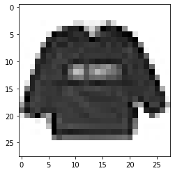

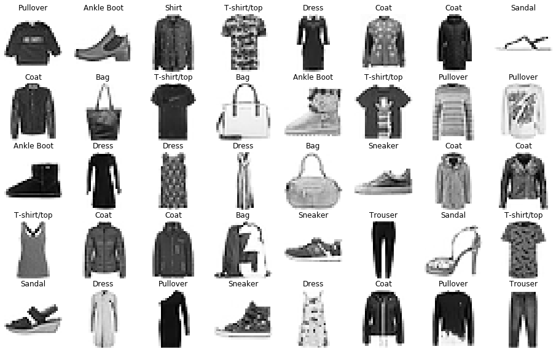

|  | label | pixel1 | pixel2 | pixel3 | pixel4 | pixel5 | pixel6 | pixel7 | pixel8 | pixel9 | ... | pixel775 | pixel776 | pixel777 | pixel778 | pixel779 | pixel780 | pixel781 | pixel782 | pixel783 | pixel784 |
| --- | --- | --- | --- | --- | --- | --- | --- | --- | --- | --- | --- | --- | --- | --- | --- | --- | --- | --- | --- | --- | --- |
| total | 0 | 0 | 0 | 0 | 0 | 0 | 0 | 0 | 0 | 0 | ... | 0 | 0 | 0 | 0 | 0 | 0 | 0 | 0 | 0 | 0 |
| percentage | 0 | 0 | 0 | 0 | 0 | 0 | 0 | 0 | 0 | 0 | ... | 0 | 0 | 0 | 0 | 0 | 0 | 0 | 0 | 0 | 0 |
| types | int64 | int64 | int64 | int64 | int64 | int64 | int64 | int64 | int64 | int64 | ... | int64 | int64 | int64 | int64 | int64 | int64 | int64 | int64 | int64 | int64 |

3 rows × 785 columns

|  | label | pixel1 | pixel2 | pixel3 | pixel4 | pixel5 | pixel6 | pixel7 | pixel8 | pixel9 | ... | pixel775 | pixel776 | pixel777 | pixel778 | pixel779 | pixel780 | pixel781 | pixel782 | pixel783 | pixel784 |
| --- | --- | --- | --- | --- | --- | --- | --- | --- | --- | --- | --- | --- | --- | --- | --- | --- | --- | --- | --- | --- | --- |
| total | 0 | 0 | 0 | 0 | 0 | 0 | 0 | 0 | 0 | 0 | ... | 0 | 0 | 0 | 0 | 0 | 0 | 0 | 0 | 0 | 0 |
| percentage | 0 | 0 | 0 | 0 | 0 | 0 | 0 | 0 | 0 | 0 | ... | 0 | 0 | 0 | 0 | 0 | 0 | 0 | 0 | 0 | 0 |
| types | int64 | int64 | int64 | int64 | int64 | int64 | int64 | int64 | int64 | int64 | ... | int64 | int64 | int64 | int64 | int64 | int64 | int64 | int64 | int64 | int64 |

3 rows × 785 columns

|  | label | pixel1 | pixel2 | pixel3 | pixel4 | pixel5 | pixel6 | pixel7 | pixel8 | pixel9 | ... | pixel775 | pixel776 | pixel777 | pixel778 | pixel779 | pixel780 | pixel781 | pixel782 | pixel783 | pixel784 |
| --- | --- | --- | --- | --- | --- | --- | --- | --- | --- | --- | --- | --- | --- | --- | --- | --- | --- | --- | --- | --- | --- |
| total | 0 | 0 | 0 | 0 | 0 | 0 | 0 | 0 | 0 | 0 | ... | 0 | 0 | 0 | 0 | 0 | 0 | 0 | 0 | 0 | 0 |
| percentage | 0 | 0 | 0 | 0 | 0 | 0 | 0 | 0 | 0 | 0 | ... | 0 | 0 | 0 | 0 | 0 | 0 | 0 | 0 | 0 | 0 |
| types | category | int64 | int64 | int64 | int64 | int64 | int64 | int64 | int64 | int64 | ... | int64 | int64 | int64 | int64 | int64 | int64 | int64 | int64 | int64 | int64 |

3 rows × 785 columns

|  | label | pixel1 | pixel2 | pixel3 | pixel4 | pixel5 | pixel6 | pixel7 | pixel8 | pixel9 | ... | pixel775 | pixel776 | pixel777 | pixel778 | pixel779 | pixel780 | pixel781 | pixel782 | pixel783 | pixel784 |
| --- | --- | --- | --- | --- | --- | --- | --- | --- | --- | --- | --- | --- | --- | --- | --- | --- | --- | --- | --- | --- | --- |
| total | 0 | 0 | 0 | 0 | 0 | 0 | 0 | 0 | 0 | 0 | ... | 0 | 0 | 0 | 0 | 0 | 0 | 0 | 0 | 0 | 0 |
| percentage | 0 | 0 | 0 | 0 | 0 | 0 | 0 | 0 | 0 | 0 | ... | 0 | 0 | 0 | 0 | 0 | 0 | 0 | 0 | 0 | 0 |
| types | category | int64 | int64 | int64 | int64 | int64 | int64 | int64 | int64 | int64 | ... | int64 | int64 | int64 | int64 | int64 | int64 | int64 | int64 | int64 | int64 |

3 rows × 785 columns

## Models

### Model 1: Generate a model using Naive Bayes

```
Wall time: 3.28 s
```

```
Accuracy: 0.5914
```

```
Confusion matrix, without normalization
[[594  42  25 196  87   0  16   0  40   0]
 [  0 940  16  33   2   1   8   0   0   0]
 [  4   7 324  68 553   0  21   0  23   0]
 [  6 311   6 644  25   0   5   0   3   0]
 [  0  33  37 155 765   0   1   0   9   0]
 [  1   1   1   2   0 289   6 648  14  38]
 [113  32 103 236 432   0  38   0  46   0]
 [  0   0   0   0   0   3   0 978   0  19]
 [  1   2  17  79 161   3  22   3 711   1]
 [  0   0   0   1   0  27   2 328  11 631]]
```

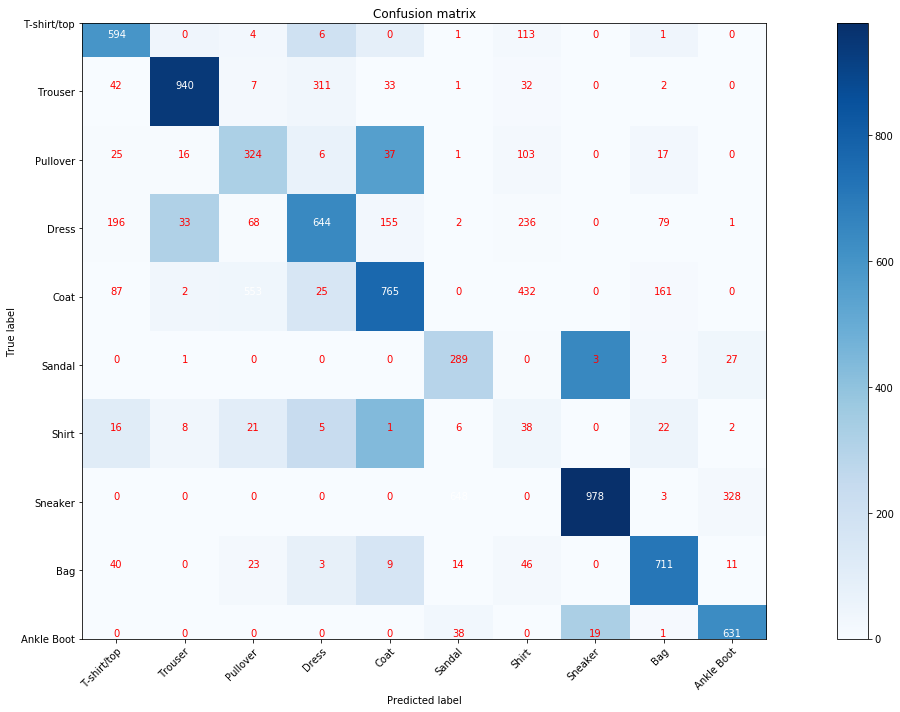

### Model 2 :Generate a model using Random Forest

```
Wall time: 4min 51s
```

```
Accuracy: 0.6634
```

```
Confusion matrix, without normalization
[[355 255 175 113  72  18   8   3   1   0]
 [  0 931  40  22   6   0   0   1   0   0]
 [  2   3 450 334 168  34   9   0   0   0]
 [  1  13 126 747 101  10   2   0   0   0]
 [  0   0  11 207 682  84  12   4   0   0]
 [  0   0   0   1   4 767 169  50   7   2]
 [ 10  42 102 138 237 196 266   7   2   0]
 [  0   0   0   0   0   9  62 823  91  15]
 [  0   1   1   2  15  20  45 114 802   0]
 [  0   0   0   0   0   1   6  38 144 811]]
```

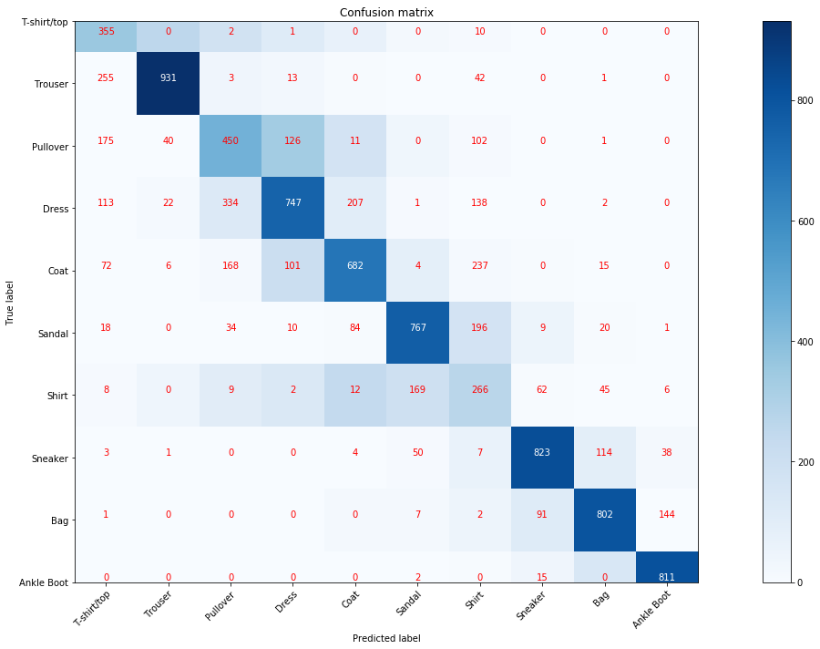

### Model 3: Generate a model using Gradient Boost

```
Learning rate:  0.05
Accuracy score (training): 0.710
Accuracy score (validation): 0.711
Learning rate:  0.075
Accuracy score (training): 0.720
Accuracy score (validation): 0.722
Learning rate:  0.1
Accuracy score (training): 0.730
Accuracy score (validation): 0.729
Learning rate:  0.25
Accuracy score (training): 0.755
Accuracy score (validation): 0.755
Learning rate:  0.5
Accuracy score (training): 0.774
Accuracy score (validation): 0.775
Learning rate:  0.75
Accuracy score (training): 0.788
Accuracy score (validation): 0.783
Learning rate:  1
Accuracy score (training): 0.786
Accuracy score (validation): 0.780
Learning rate:  1.25
Accuracy score (training): 0.789
Accuracy score (validation): 0.777
Learning rate:  1.5
Accuracy score (training): 0.098
Accuracy score (validation): 0.098
Learning rate:  1.75
Accuracy score (training): 0.106
Accuracy score (validation): 0.106
```

```
Wall time: 9.22 s
```

```
Accuracy: 0.78
```

```
Confusion matrix, without normalization
[[729  10  15  71  17   5 119   1  33   0]
 [  6 926   9  39  11   2   5   1   1   0]
 [ 13   8 659   9 154   1 140   0  16   0]
 [ 38  38   8 813  54   1  40   0   8   0]
 [  6  10 159  45 684   1  88   0   7   0]
 [  1   2   2   1   0 848   0  93   6  47]
 [164   9 119  48 132   5 488   0  35   0]
 [  0   0   0   0   0  60   0 856   4  80]
 [  2   5  16  15   9  14  28   8 901   2]
 [  0   0   1   0   0  29   2  64   8 896]]
```

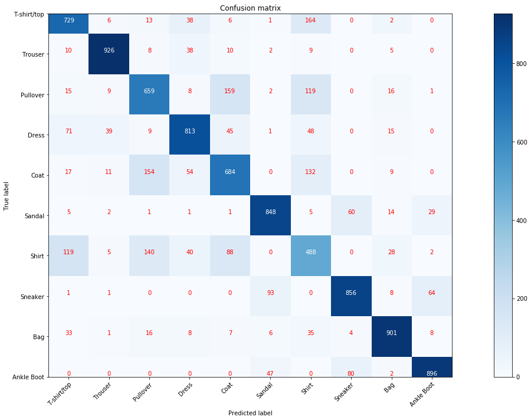

### Model 4: Generate a model using XGBoost

```
Score :0.8674
Wall time: 32min 4s
```

```
Accuracy: 0.8674
```

```
Confusion matrix, without normalization
[[830   2  11  39   1   1 102   0  14   0]
 [  3 977   4  11   2   1   2   0   0   0]
 [ 10   0 787   9 113   0  70   0  11   0]
 [ 26   9  11 905  24   1  23   0   1   0]
 [  1   1  87  36 811   0  60   0   4   0]
 [  0   0   0   0   0 924   3  54   3  16]
 [180   2 103  23  76   0 602   0  14   0]
 [  0   0   0   0   0   9   0 922   1  68]
 [  2   2   8   2   2   5  13   2 963   1]
 [  0   0   0   0   0   5   1  39   2 953]]
```

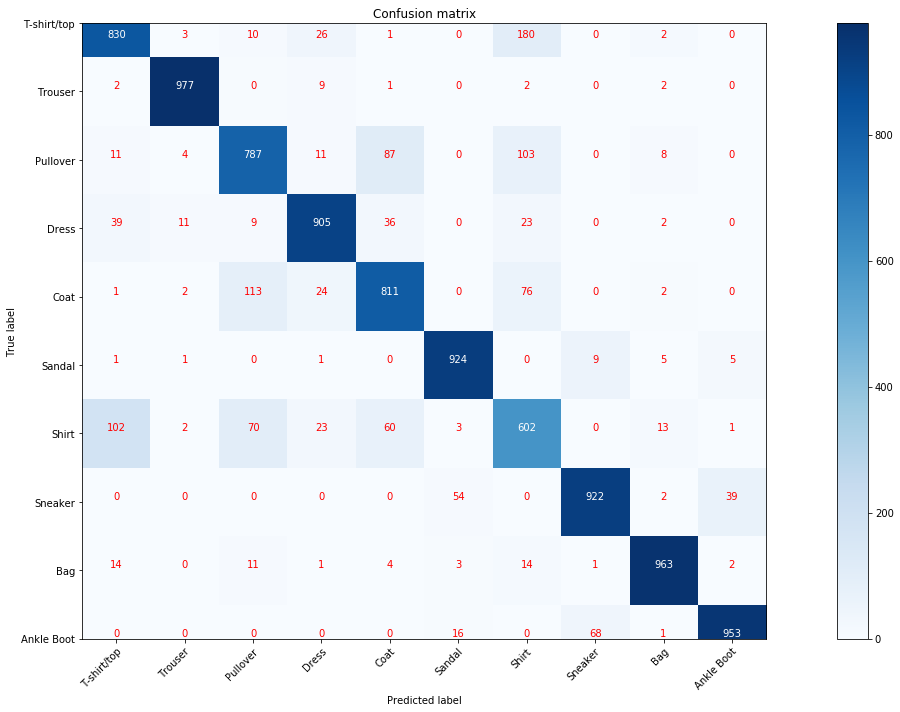

### Model 5: Generate a Model using Gradient Descent in TensorFlow

[output not shown]

```
b'Hello, TensorFlow!'
```

|  | label | pixel1 | pixel2 | pixel3 | pixel4 | pixel5 | pixel6 | pixel7 | pixel8 | pixel9 | ... | pixel775 | pixel776 | pixel777 | pixel778 | pixel779 | pixel780 | pixel781 | pixel782 | pixel783 | pixel784 |
| --- | --- | --- | --- | --- | --- | --- | --- | --- | --- | --- | --- | --- | --- | --- | --- | --- | --- | --- | --- | --- | --- |
| 0 | 2 | 0 | 0 | 0 | 0 | 0 | 0 | 0 | 0 | 0 | ... | 0 | 0 | 0 | 0 | 0 | 0 | 0 | 0 | 0 | 0 |
| 1 | 9 | 0 | 0 | 0 | 0 | 0 | 0 | 0 | 0 | 0 | ... | 0 | 0 | 0 | 0 | 0 | 0 | 0 | 0 | 0 | 0 |
| 2 | 6 | 0 | 0 | 0 | 0 | 0 | 0 | 0 | 5 | 0 | ... | 0 | 0 | 0 | 30 | 43 | 0 | 0 | 0 | 0 | 0 |
| 3 | 0 | 0 | 0 | 0 | 1 | 2 | 0 | 0 | 0 | 0 | ... | 3 | 0 | 0 | 0 | 0 | 1 | 0 | 0 | 0 | 0 |
| 4 | 3 | 0 | 0 | 0 | 0 | 0 | 0 | 0 | 0 | 0 | ... | 0 | 0 | 0 | 0 | 0 | 0 | 0 | 0 | 0 | 0 |

5 rows × 785 columns

```
0.307
```

### Model 6: Generate a Model using TensorFlow and Convolution layers

```
training accuracy 0.1
test accuracy 0.1
```

## Results and Conclusion

[figure not shown]